[figure not shown]

# Variável Aleatória - Aplicações

## Distribuições de Probabilidades

### Bibliotecas

```python
import pandas as pd
import numpy as np
import matplotlib.pyplot as plt
import matplotlib.colors as mcolors
import seaborn as sns
from scipy.stats import uniform
from scipy.stats import poisson
from scipy.stats import binom
from scipy.stats import norm
import math
```

### Distribuição Uniforme Discreta

Neste arquivo traremos as aplicações das distribuições de probabilidades. Começaremos pela distribuição uniforme discreta.

$$ \mathbb{P}_{X} (X = x) = \frac{1}{N}\mathbb{1}_{\{1,2,\dots,N\}^{(x)}}$$

```python
np.random.seed(123)
dunif = np.random.choice(np.arange(1, 11), size=10, replace=False)
dunif = pd.DataFrame(dunif, columns=["dist_unif_disc"])
dunif
```

|  | dist_unif_disc |
| --- | --- |
| 0 | 5 |
| 1 | 1 |
| 2 | 8 |
| 3 | 6 |
| 4 | 9 |
| 5 | 4 |
| 6 | 2 |
| 7 | 7 |
| 8 | 10 |
| 9 | 3 |

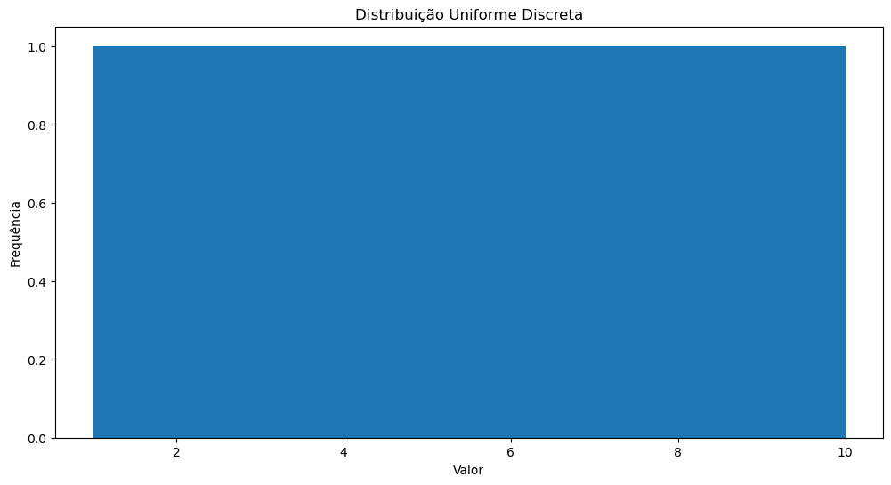

```python
plt.figure(figsize=(12,6))
plt.hist(dunif['dist_unif_disc'], bins=10)
plt.xlabel('Valor')
plt.ylabel('Frequência')
plt.title('Distribuição Uniforme Discreta')
plt.show()
```

### Distribuição Uniforme Contínua

Agora veremos um exemplo aplicado da distribuição uniforme contínua.

\begin{align*} \begin{cases} f_{X} (X = x) = \frac{1}{(b-a)}\mathbb{1}_{\{a,b\}^{(x)}} \\ \mathbb{E}(X) = \frac{(a+b)}{2} \\ \mathbb{V}(X) = \frac{(b-a)^{2}}{12} \end{cases} \end{align*}

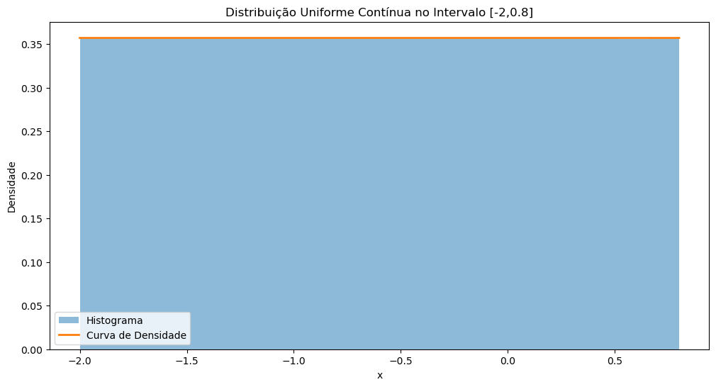

```python
# Set random seed
np.random.seed(123)

# Set parameters
a = -2
b = 0.8

# Generate random uniform distribution
rand_unif = np.random.uniform(low=a, high=b, size=10000000)

# Plot histogram with density curve
plt.figure(figsize=(12,6))
plt.hist(rand_unif, density=True, bins=20, alpha=0.5, label='Histograma')
plt.plot(np.linspace(a,b,10000), uniform.pdf(np.linspace(a,b,10000), loc=a, scale=b-a),
         label='Curva de Densidade', linewidth=2)
plt.xlabel('x')
plt.ylabel('Densidade')
plt.title('Distribuição Uniforme Contínua no Intervalo [-2,0.8]')
plt.legend()
plt.show()
```

### Distribuição de Poison

Quando uma variável aleatória apresenta Distribuição de Poisson, dizemos que $X \sim Poisson (\lambda)$, onde $\lambda > 0$ é o parâmetro que representa a **Taxa de Ocorrência** do evento de interesse e $X = \{0, 1, 2, \dots \}$. Para essa variável aleatória temos:

#### Exemplo de Número de Bebês Nascidos em um Hospital

Imagine que os dados do Hospital Born Hospital, hospital no qual você trabalha como analista de dados e risco, demonstram que a média de nascimentos de bebês nascidos neste hospital é de 4, 5 bebês por dias. A gerência gostaria que você simula-se uma distribuição e apresenta-se a eles a probabilidades e informações adicionais caso nasça 6 bebês amanhã?

Com isso você irá apresentar um relatório com informações para a direção do hospital se preparar para esse evento:

\begin{align*} \begin{cases} \mathbb{P}_{X} (X = x) = \frac{e^{-\lambda} \lambda^{x} }{ x! } \quad com = \{0,1,2, \dots \} \\ \mathbb{E}(X) = \lambda \\ \mathbb{V}(X) = \lambda \end{cases} \end{align*}

```python
# Set random seed
np.random.seed(123)

# Set lambda parameter
lam = 4.5

# Calculate Poisson PMF at x=6
pois_pmf = poisson.pmf(6, mu=lam)

# Round and scale to percentage
pois_dist = round(pois_pmf, 2) * 100

# Print result
print("A probabilidade Teórica de 6 bebês nascerem amanhã é de", pois_dist, "%")
```

```
A probabilidade Teórica de 6 bebês nascerem amanhã é de 13.0 %
```

Agora no relatório você irá apresentar uma visualização dos dados simulados para o nascimento, com esses parâmetros, em um ano ($n = 365$ dias).

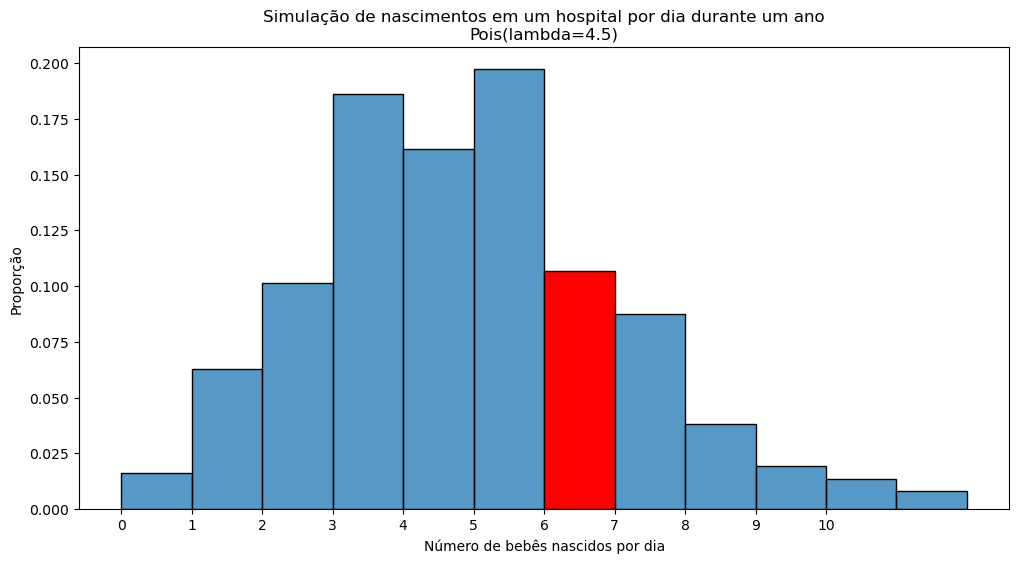

```python
# Set random seed
np.random.seed(123)

# Simulate Poisson distribution of babies born per day for a year
babies = pd.DataFrame({'data': np.random.poisson(lam=4.5, size=365)})

# Set figure size
plt.figure(figsize=(12, 6))

# Create histogram with ggplot
ax = sns.histplot(data=babies, x='data', binwidth=1, stat='probability')

plt.xticks(range(11))
plt.xlabel('Número de bebês nascidos por dia')
plt.ylabel('Proporção')
plt.title('Simulação de nascimentos em um hospital por dia durante um ano\nPois(lambda=4.5)')

# Draw vertical lines at x=6 and x=7
ax.patches[6].set_facecolor('red')

sns.set_style('white')
plt.show()
```

#### Exemplo Chamadas telefônicas da aula

Considere uma central de atendimento que recebe $5$ telefonemas a cada $3$ minutos. Qual é a probabilidade dessa central receber pelo menos duas chamadas? Qual a probabilidade de não receber chamada alguma?

```python
P = (1 - (math.exp(-5)*5 + math.exp(-5)) )* 100
P = round(P, 2)
print("A probabilidade de receber ao menos duas chamadas é de ", P, "%")
```

```
A probabilidade de receber ao menos duas chamadas é de  95.96 %
```

```python
P = (math.exp(-5))*100
P = round(P, 2)
print("A probabilidade de não receber chamada alguma é de ", P, "%")
```

```
A probabilidade de não receber chamada alguma é de  0.67 %
```

### Distribuição de Binomial

Para uma variável aleatória $X \sim Binomial (n, p)$, temos $X = \{0, 1, 2, . . . , n\}$, tal que:

\begin{align*} \begin{cases} \mathbb{P}_{X} (X = x) = \binom{n}{x} p^{x}(1-p)^{n-x} \quad com \quad x = \{0,1,2, \dots, n \} \\ \mathbb{E}(X) = n \cdot p\\ \mathbb{V}(X) = np \cdot (1-p) \end{cases} \end{align*}

#### Exemplo de uma aplicação de Overbooking em um voô de uma companhia aérea

Suponha que você foi denominado para demostrar a chances e apresentar uma simulação de ocorrência de overbooking para uma determinada empresa de transporte aéreo de passageiros.

O voô analisado possui uma aeronave com capacidade para $100$ passageiros, e a empresa espera vender $110$ passagens aéreas. Isso é feito, pois é bem comum que todos os passageiros não comparaçam na hora certa do voô. Em primeiro plano você gerou uma análise do histórico desses eventos e descobriu que a chance de as pessoas não comparecerem possui uma média de $p = 12\%$. A probabilidade das pessoas aparecerem no horário portanto é de $1 − p = 88\%$.

Pergunta-se, qual é a probabilidade de uma pessoa aparecer nesse voô de 100 passageiros analisados e ocorrer o overbooking?

```python
P_100 = 100 * (1 - binom.cdf(100, 110, 0.88))
P_100 = round(P_100, 2)
print("A Probabilidade de ocorrer o Overbooking é de", P_100, "%")
```

```
A Probabilidade de ocorrer o Overbooking é de 13.67 %
```

O valor de ocorrência do overbooking é de $13, 67\%$, essa probabilidade é muito alta, com isso o pessoal da direção da empresa pede que você desenvolva algo que possa mitigar esse risco. A empresa pede que você desenvolva algo que assuma no máximo um risco de $5\%$.

Com isso você primeiro desenvolve uma aplicação gráfica:

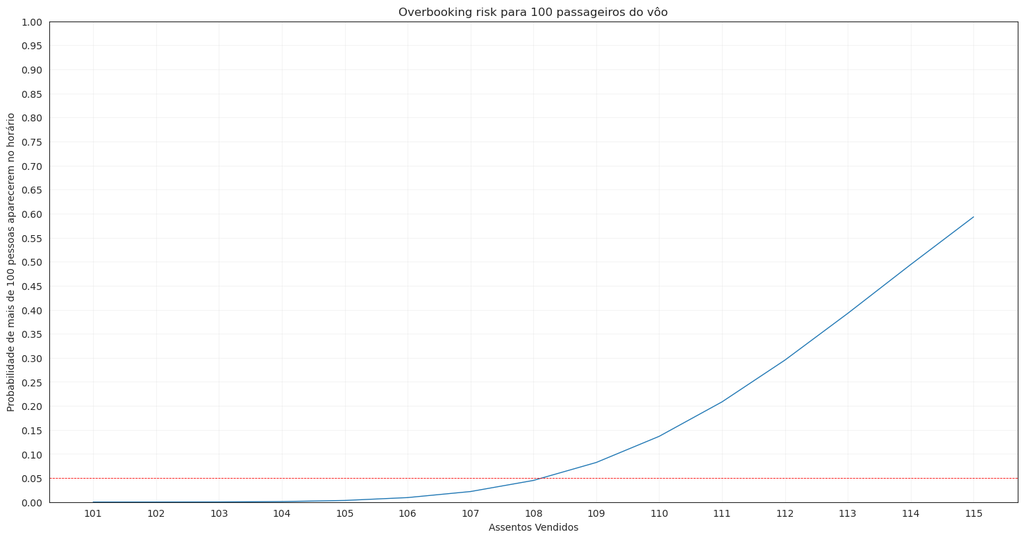

```python
p = 0.88
seats_sold = np.arange(101, 116)
probability = 1 - binom.cdf(100, seats_sold, p)

fig, ax = plt.subplots(figsize=(18, 9))

ax.plot(seats_sold, probability, linewidth=1)
ax.axhline(y=0.05, color='red', linestyle='--', linewidth=0.6)
ax.set_xlabel('Assentos Vendidos')
ax.set_ylabel('Probabilidade de mais de 100 pessoas aparecerem no horário')
ax.set_title('Overbooking risk para 100 passageiros do vôo', fontsize=12)
ax.set_xticks(np.arange(101, 116))
ax.set_yticks(np.arange(0, 1.05, 0.05))
ax.set_ylim([0, 1])
ax.grid(alpha=0.2)

plt.show()
```

Olhando pelo gráfico acima parece que o número ideal de passagens a ser vendidas é de $108$ passagens para se assumir um risco de $5\%$ de ocorrência de overbooking.

Com isso podemos ver os resultados em uma tabela:

```python
table = pd.DataFrame({'seats_sold': seats_sold, 'probability': probability})
table = table.iloc[6:9, :]  # selecting rows 7 to 9
print(table)
```

```
   seats_sold  probability
6         107     0.021845
7         108     0.044926
8         109     0.082317
```

```python
tab = table.iloc[1, :]
print("A Probabilidade de vender 108 passagens e ocorrer ao menos um overbooking é de",
      round(tab["probability"], 4)*100, "%")
```

```
A Probabilidade de vender 108 passagens e ocorrer ao menos um overbooking é de 4.49 %
```

### Distribuição Normal

```python
mean = 100
sd = 15
lb = 80
ub = 120

p_ub = round(norm.cdf(ub, mean, sd), 4)
p_lb = round(norm.cdf(lb, mean, sd), 4)

area = norm.cdf(ub, mean, sd) - norm.cdf(lb, mean, sd)

result = round(area, 4) * 100

print("A Probabilidade é:", result, "%")
```

```
A Probabilidade é: 81.76 %
```

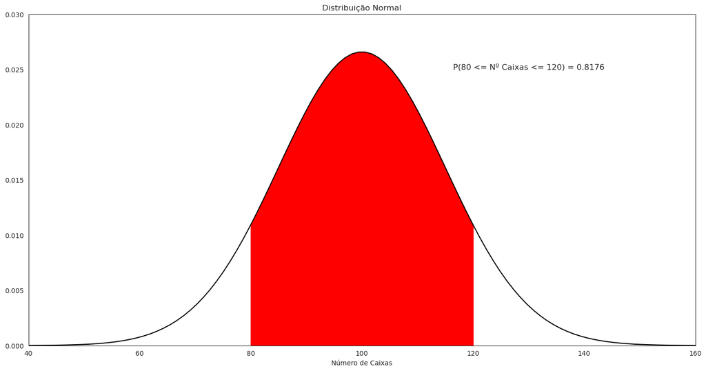

```python
mean = 100
sd = 15
lb = 80
ub = 120

area = norm.cdf(ub, mean, sd) - norm.cdf(lb, mean, sd)

result = "P(" + str(lb) + " <= Nº Caixas <= " + str(ub) + ") = " + str(round(area, 4))

x = np.linspace(40, 160, 100)
hx = norm.pdf(x, mean, sd)

i = (x >= lb) & (x <= ub)

fig, ax = plt.subplots(figsize=(18,9))

ax.plot(x, hx, 'k', linewidth=1.5)
ax.fill_between(x, hx, 0, where=i, color='red', alpha=1)
ax.set_xlim([40, 160])
ax.set_ylim([0, 0.03])
ax.set_xlabel("Número de Caixas")
ax.set_title("Distribuição Normal")
ax.text(130, 0.025, result, ha='center', fontsize=12)
ax.set_xticks(np.arange(40, 161, 20))

plt.show()
```